# Matching

Linh Tran

5/18/2021

# `MatchIt`

`MatchIt` provides a simple and straightforward interface to various methods of matching for covariate balance in observational studies. Several matching methods are available: nearest neighbor matching, optimal pair matching, optimal full matching, genetic matching, exact matching, subclassification,…. After preprocessing with `MatchIt`, we can use whatever parametric model they would have used without `MatchIt` and produce inferences that are more robust and less sensitive to modeling assumptions. Here is an example of the use of `MatchIt` to perform full matching and assess balance.

Goal of matching is to produce *covariate balance*, that is, for the distributions of covariates in the 2 groups to be approximately equal to each other, as they would be in a randomized experiment. In perfectly balanced samples, a simple difference in means can be a valid treatment effect estimate.

```r
data("lalonde")
head(lalonde)
```

```
##      treat age educ   race married nodegree re74 re75       re78
## NSW1     1  37   11  black       1        1    0    0  9930.0460
## NSW2     1  22    9 hispan       0        1    0    0  3595.8940
## NSW3     1  30   12  black       0        0    0    0 24909.4500
## NSW4     1  27   11  black       0        1    0    0  7506.1460
## NSW5     1  33    8  black       0        1    0    0   289.7899
## NSW6     1  22    9  black       0        1    0    0  4056.4940
```

`treat` is the treatment variable, `re78` is the outcome, and the others are pre-treatment variable. We are interested in the causal effect of the treatment (`treat`) on 1978 earnings (`re78`)

# Planning:

Select type of effect to be estimated, target population to which the treatment effect is to generalize, select the covariates for which balance is required for an unbiased estimate of the treatment effect.

### Select type of effect to be estimated

Matching is well-suited for estimating total effects.*Conditional effect* = effect of treatment within some strata of other prognostic variable. * Marginal effect* = average effect of a treatment in a population (e.g., for implementing a broad policy change)

### Selecting target population

Target population = population to which the effect estimate is to generalize. Usually the target population is a group of units who are eligible for the treatment.  
The average treatment effect in the population (ATE) = average effect of treatment for all units in the target population.  
The average treatment effect in the treated (ATT) = average treatment for units like those who were actually treated.

### Selecting covariates to balance

To estimate total causal effects, all covariates must be measured prior to treatment (or otherwise not be affected by the treatment)

# Check initial imbalance

`method` argument specifies the method of matching to be performed. `method` = NULL => assess balance prior to matching. `distance` specifies the method for estimating propensity score computed as the predicted probability of being the treated group given the covariates.

```r
# Constructing a pre-match matchit object
m.out0 <- matchit(treat ~ age + educ + race + married + nodegree + re74 + re75,
                  data = lalonde,
                  method = NULL, distance = "glm") #logistic regression


summary(m.out0)
```

```
##
## Call:
## matchit(formula = treat ~ age + educ + race + married + nodegree +
##     re74 + re75, data = lalonde, method = NULL, distance = "glm")
##
## Summary of Balance for All Data:
##            Means Treated Means Control Std. Mean Diff. Var. Ratio eCDF Mean
## distance          0.5774        0.1822          1.7941     0.9211    0.3774
## age              25.8162       28.0303         -0.3094     0.4400    0.0813
## educ             10.3459       10.2354          0.0550     0.4959    0.0347
## raceblack         0.8432        0.2028          1.7615          .    0.6404
## racehispan        0.0595        0.1422         -0.3498          .    0.0827
## racewhite         0.0973        0.6550         -1.8819          .    0.5577
## married           0.1892        0.5128         -0.8263          .    0.3236
## nodegree          0.7081        0.5967          0.2450          .    0.1114
## re74           2095.5737     5619.2365         -0.7211     0.5181    0.2248
## re75           1532.0553     2466.4844         -0.2903     0.9563    0.1342
##            eCDF Max
## distance     0.6444
## age          0.1577
## educ         0.1114
## raceblack    0.6404
## racehispan   0.0827
## racewhite    0.5577
## married      0.3236
## nodegree     0.1114
## re74         0.4470
## re75         0.2876
##
##
## Sample Sizes:
##           Control Treated
## All           429     185
## Matched       429     185
## Unmatched       0       0
## Discarded       0       0
```

```r
m.out0
```

```
## A matchit object
##  - method: None (no matching)
##  - distance: Propensity score
##              - estimated with logistic regression
##  - number of obs.: 614 (original)
##  - target estimand: ATT
##  - covariates: age, educ, race, married, nodegree, re74, re75
```

We can see severe imbalances as measured by the standardized mean differences (Std. Mean diff), variance ratio (Var. Ratio) and empirical cumulative density function (eCDF) statistics. Ideally standardized mean differences and eCDF statistics close to 0, variance ratios close to 1 indicate good balance. Here many of them are far from their ideal values.

# Matching

## 1:1 nearest neighbor (NN)

One by one, each treated unit is paired with an available control unit that has the closest propensity score to it. Any remaining control units are left unmatched and excluded from further analysis

```r
# 1:1 NN PS matching w/o replacement
m.out1 <- matchit(treat ~ age + educ + race + married +
                   nodegree + re74 + re75, data = lalonde,
                 method = "nearest", distance = "glm")


m.out1
```

```
## A matchit object
##  - method: 1:1 nearest neighbor matching without replacement
##  - distance: Propensity score
##              - estimated with logistic regression
##  - number of obs.: 614 (original), 370 (matched)
##  - target estimand: ATT
##  - covariates: age, educ, race, married, nodegree, re74, re75
```

```r
lalonde %>%
  group_by(treat) %>%
 summarize(n_obs = n())
```

```
## # A tibble: 2 x 2
##   treat n_obs
##   <int> <int>
## 1     0   429
## 2     1   185
```

- We have:
  - balance for the original sample
  - balance in the matched sample
  - percent reduction in imbalance
  - sample size before and after matching Smaller values for the balance statistics indicate better balance.

We can plot the standardized mean differences in a Love plot for a visual display of balance across sample:

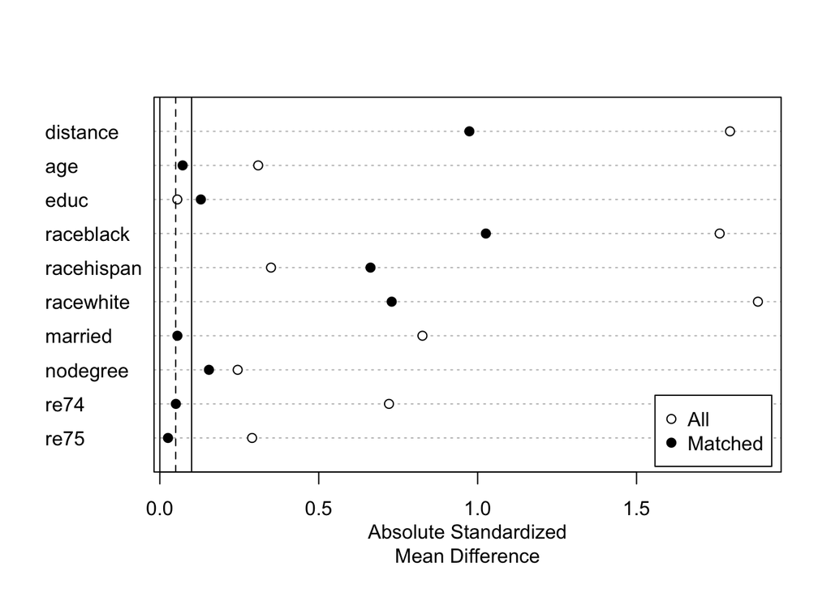

```r
# plot balance
plot(summary(m.out1))
```

# Assessing the quality of matches

Check for covariate balance, quality of match (how many units remain after matching).

If, after matching, the remaining sample size is small => resulting effect estimate might not be accurate. There will be a trade-off between balance and remaining sample size.

To assess quality of resulting matches, we can use `summary()` function.

```r
summary(m.out1)
```

```
##
## Call:
## matchit(formula = treat ~ age + educ + race + married + nodegree +
##     re74 + re75, data = lalonde, method = "nearest", distance = "glm")
##
## Summary of Balance for All Data:
##            Means Treated Means Control Std. Mean Diff. Var. Ratio eCDF Mean
## distance          0.5774        0.1822          1.7941     0.9211    0.3774
## age              25.8162       28.0303         -0.3094     0.4400    0.0813
## educ             10.3459       10.2354          0.0550     0.4959    0.0347
## raceblack         0.8432        0.2028          1.7615          .    0.6404
## racehispan        0.0595        0.1422         -0.3498          .    0.0827
## racewhite         0.0973        0.6550         -1.8819          .    0.5577
## married           0.1892        0.5128         -0.8263          .    0.3236
## nodegree          0.7081        0.5967          0.2450          .    0.1114
## re74           2095.5737     5619.2365         -0.7211     0.5181    0.2248
## re75           1532.0553     2466.4844         -0.2903     0.9563    0.1342
##            eCDF Max
## distance     0.6444
## age          0.1577
## educ         0.1114
## raceblack    0.6404
## racehispan   0.0827
## racewhite    0.5577
## married      0.3236
## nodegree     0.1114
## re74         0.4470
## re75         0.2876
##
##
## Summary of Balance for Matched Data:
##            Means Treated Means Control Std. Mean Diff. Var. Ratio eCDF Mean
## distance          0.5774        0.3629          0.9739     0.7566    0.1321
## age              25.8162       25.3027          0.0718     0.4568    0.0847
## educ             10.3459       10.6054         -0.1290     0.5721    0.0239
## raceblack         0.8432        0.4703          1.0259          .    0.3730
## racehispan        0.0595        0.2162         -0.6629          .    0.1568
## racewhite         0.0973        0.3135         -0.7296          .    0.2162
## married           0.1892        0.2108         -0.0552          .    0.0216
## nodegree          0.7081        0.6378          0.1546          .    0.0703
```

[output cut: 18 more lines]

```
## educ                -134.8       20.4      31.2     32.1
## raceblack             41.8          .      41.8     41.8
## racehispan           -89.5          .     -89.5    -89.5
## racewhite             61.2          .      61.2     61.2
## married               93.3          .      93.3     93.3
## nodegree              36.9          .      36.9     36.9
## re74                  93.0       56.8      79.1     38.3
## re75                  91.2     -800.7      66.3     28.6
##
## Sample Sizes:
##           Control Treated
## All           429     185
## Matched       185     185
## Unmatched     244       0
## Discarded       0       0
```

Although balance has improved for some covariates, in general balance is still quite poor, indicating that NN PSM is not sufficient for removing confounding in this dataset. The final column `Std.Pair Diff`displays the average absolute within-pair difference of each covariate. Small values indicate better balance.

Table of sample sizes before and after matching:244 unmatched control units. ideally, unmatched units would be far from treated units and would require greater extrapolation were they to have been retained. We can visualize the distribution of PS of those who were matched :

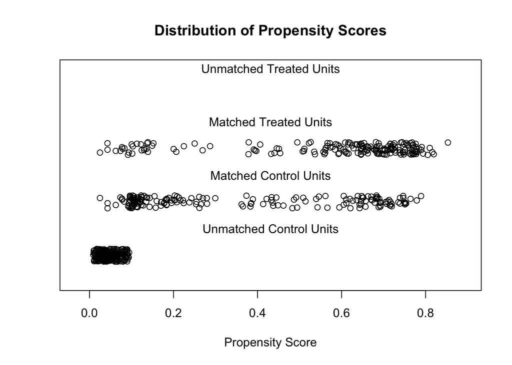

```r
plot(m.out1, type = "jitter", interactive = FALSE)
```

We can visually examine balance on the covariates using `plot()` with `type = "qq"`

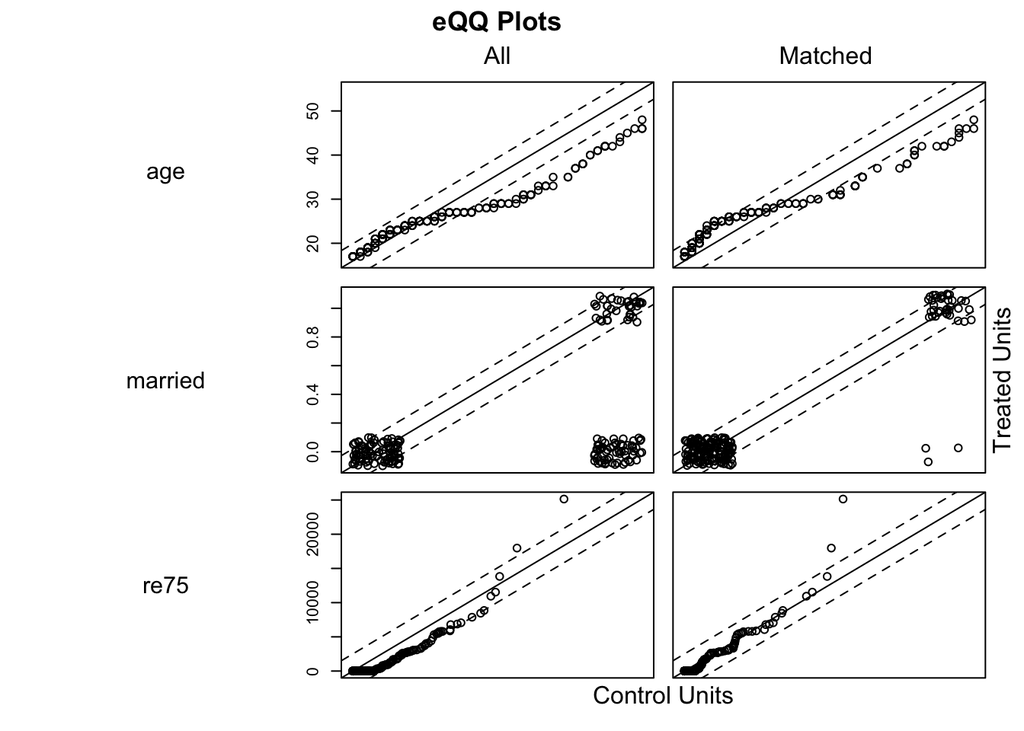

```r
plot(m.out1, type = "qq", interactive = FALSE,
     which.xs = c("age", "married", "re75"))
```

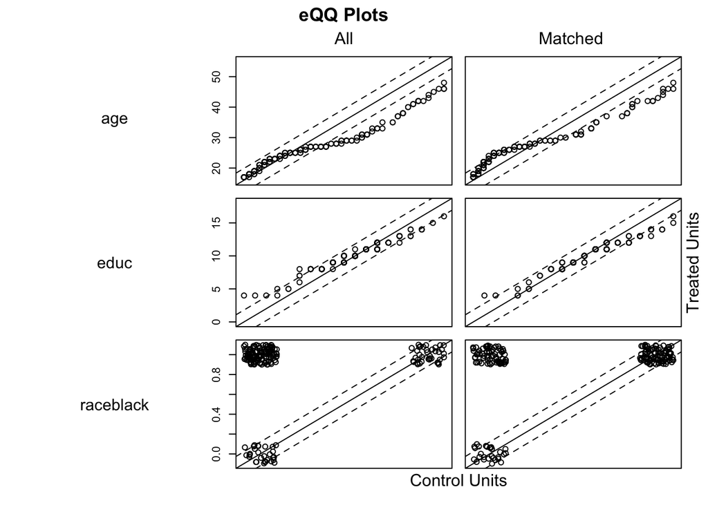

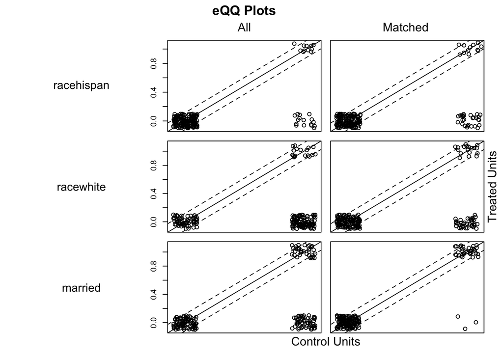

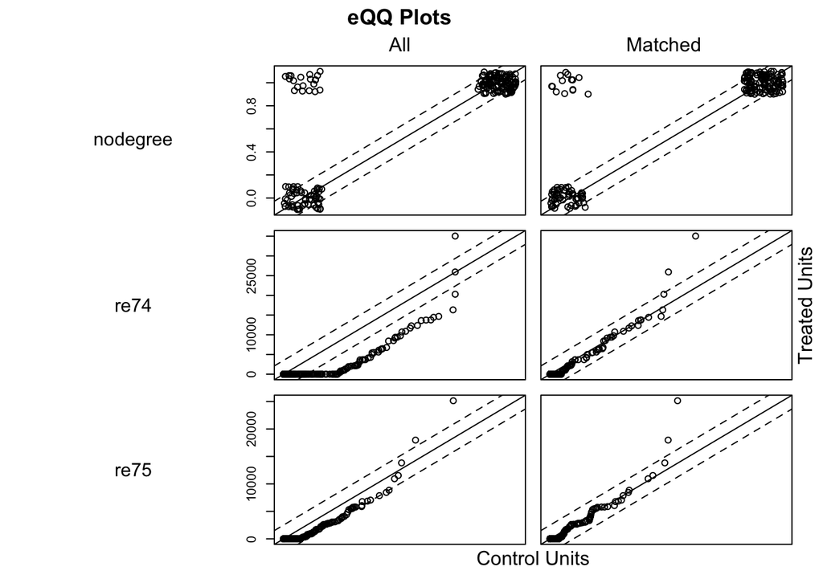

```r
plot(m.out1, )
```

Points are far from the solid diagonal line are the areas of the covariate distributions that differ between the treatment groups. Although `married` and `re75` appear to have improved balance after matching, the case is mixed for `age`. Ideally we want to see the points in the right column (matched) falling between the dotted lines.

## Trying a Different Matching Specification

Given the poor performance of nearest neighbor matching, we can try a different matching method or make other changes to the matching algorithm or distance specification. Below, we will try full matching, which matches every treated units to at least one control and every control to at least one treated units. We’ll also try a different link (probit) for the propensity score model

```r
# Full matching on a probit PS
m.out2 <- matchit(treat ~ age + educ + race + married + nodegree + re74 + re75,
                  data = lalonde,
                  method = "full",
                  distance = "glm",
                  link = "probit")

m.out2
```

```
## A matchit object
##  - method: Optimal full matching
##  - distance: Propensity score
##              - estimated with probit regression
##  - number of obs.: 614 (original), 614 (matched)
##  - target estimand: ATT
##  - covariates: age, educ, race, married, nodegree, re74, re75
```

We can examine balance on this new matching specification

```r
# Checking balance
summary(m.out2)
```

```
##
## Call:
## matchit(formula = treat ~ age + educ + race + married + nodegree +
##     re74 + re75, data = lalonde, method = "full", distance = "glm",
##     link = "probit")
##
## Summary of Balance for All Data:
##            Means Treated Means Control Std. Mean Diff. Var. Ratio eCDF Mean
## distance          0.5773        0.1817          1.8276     0.8777    0.3774
## age              25.8162       28.0303         -0.3094     0.4400    0.0813
## educ             10.3459       10.2354          0.0550     0.4959    0.0347
## raceblack         0.8432        0.2028          1.7615          .    0.6404
## racehispan        0.0595        0.1422         -0.3498          .    0.0827
## racewhite         0.0973        0.6550         -1.8819          .    0.5577
## married           0.1892        0.5128         -0.8263          .    0.3236
## nodegree          0.7081        0.5967          0.2450          .    0.1114
## re74           2095.5737     5619.2365         -0.7211     0.5181    0.2248
## re75           1532.0553     2466.4844         -0.2903     0.9563    0.1342
##            eCDF Max
## distance     0.6413
## age          0.1577
## educ         0.1114
## raceblack    0.6404
## racehispan   0.0827
## racewhite    0.5577
## married      0.3236
## nodegree     0.1114
## re74         0.4470
## re75         0.2876
##
##
## Summary of Balance for Matched Data:
##            Means Treated Means Control Std. Mean Diff. Var. Ratio eCDF Mean
## distance          0.5773        0.5765          0.0040     0.9943    0.0042
## age              25.8162       25.6722          0.0201     0.4614    0.0848
## educ             10.3459       10.3693         -0.0116     0.6173    0.0194
## raceblack         0.8432        0.8389          0.0119          .    0.0043
## racehispan        0.0595        0.0500          0.0402          .    0.0095
## racewhite         0.0973        0.1111         -0.0467          .    0.0138
## married           0.1892        0.1580          0.0797          .    0.0312
```

[output cut: 20 more lines]

```
## raceblack             99.3          .      99.3     99.3
## racehispan            88.5          .      88.5     88.5
## racewhite             97.5          .      97.5     97.5
## married               90.4          .      90.4     90.4
## nodegree              83.5          .      83.5     83.5
## re74                  99.8       54.2      85.4     51.7
## re75                  97.8     -906.2      63.0     30.0
##
## Sample Sizes:
##               Control Treated
## All            429.       185
## Matched (ESS)   53.51     185
## Matched        429.       185
## Unmatched        0.         0
## Discarded        0.         0
```

Balance is far better, as determined by lower standardized mean differences and eCDF statistics (close to 0). The balance can be reported using table or Love plot

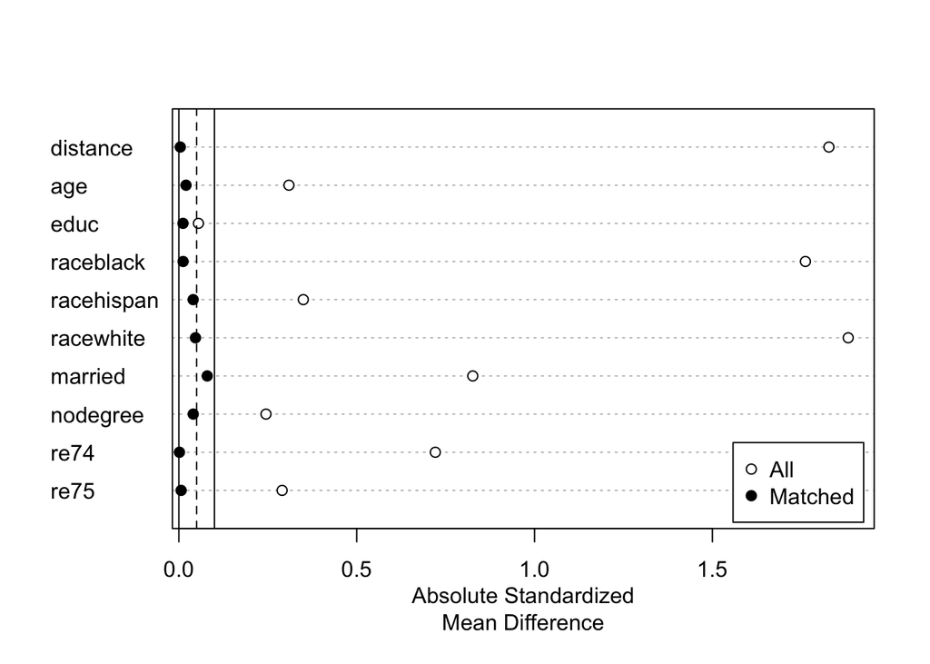

```r
plot(summary(m.out2))
```

# Estimating the Treatment Effect

How treatment effects are estimated depends on what form of matching was performed. After 1:1 matching without replacement, we can run a simple regression of the outcome on the treatment in the matched sample (i.e. including matching weights). With continuous outcomes, it is often a good idea to also include the covariates used in the matching in the effect estimation, as doing so can provide additional robustness to slight imbalances remaining after the matching and can improve precision.

First we extract the matched dataset from `matchit` object using `match.data()`. This dataset only contains the matched units and adds columns for `distance`, `weights`, and `subclass`

```r
m.data1 <- match.data(m.out1)
head(m.data1)
```

```
##      treat age educ   race married nodegree re74 re75       re78  distance
## NSW1     1  37   11  black       1        1    0    0  9930.0460 0.6387699
## NSW2     1  22    9 hispan       0        1    0    0  3595.8940 0.2246342
## NSW3     1  30   12  black       0        0    0    0 24909.4500 0.6782439
## NSW4     1  27   11  black       0        1    0    0  7506.1460 0.7763241
## NSW5     1  33    8  black       0        1    0    0   289.7899 0.7016387
## NSW6     1  22    9  black       0        1    0    0  4056.4940 0.6990699
##      weights subclass
## NSW1       1        1
## NSW2       1       98
## NSW3       1      109
## NSW4       1      120
## NSW5       1      131
## NSW6       1      142
```

We can then estimate a treatment effect using the standard regression like `lm` or `glm()`, being sure to include the matching weights `weights = weights`. Recommend using cluster-robust standard errors for most analyses, with pair membership as the clustering variable; the `lmtest` and `sandwich` packages together make this straightforward.

```r
library("lmtest") #coeftest
library("sandwich")  #vcovCL

fit1 <- lm(re78 ~ treat + age + educ + race + married + nodegree +
             re74 + re75, data = m.data1, weights = weights)

coeftest(fit1, vcov. = vcovCL, cluster = ~subclass)
```

```
##
## t test of coefficients:
##
##                Estimate  Std. Error t value Pr(>|t|)
## (Intercept) -2.5816e+03  3.3209e+03 -0.7774 0.437439
## treat        1.3449e+03  7.3084e+02  1.8403 0.066552 .
## age          7.8035e+00  4.4148e+01  0.1768 0.859797
## educ         6.0220e+02  2.1007e+02  2.8667 0.004391 **
## racehispan   1.5335e+03  1.0248e+03  1.4964 0.135417
## racewhite    4.6943e+02  8.9854e+02  0.5224 0.601687
## married     -1.5825e+02  9.3354e+02 -0.1695 0.865482
## nodegree     9.2328e+02  1.1496e+03  0.8032 0.422412
## re74         2.6362e-02  1.6646e-01  0.1584 0.874257
## re75         2.2068e-01  1.6771e-01  1.3158 0.189069
## ---
## Signif. codes:  0 '***' 0.001 '**' 0.01 '*' 0.05 '.' 0.1 ' ' 1
```

The coefficient on `treat` is the estimated treatment effect in the treated (ATT). The other coefficients and tests should not be interpreted or reported.

A benefit of matching is that the outcome model used to estimate the treatment effect is robust to misspecification when balance has been achieved. With 1:1 nearest neighbor matching, we failed to achieve balance, so one should be cautious about trusting the estimated effect. With full matching, we were able to achieve balance => effect estimate should depend less on the form of the outcome model used.

```r
m.data2 <- match.data(m.out2)
head(m.data2)
```

```
##      treat age educ   race married nodegree re74 re75       re78  distance
## NSW1     1  37   11  black       1        1    0    0  9930.0460 0.6356769
## NSW2     1  22    9 hispan       0        1    0    0  3595.8940 0.2298151
## NSW3     1  30   12  black       0        0    0    0 24909.4500 0.6813558
## NSW4     1  27   11  black       0        1    0    0  7506.1460 0.7690590
## NSW5     1  33    8  black       0        1    0    0   289.7899 0.6954138
## NSW6     1  22    9  black       0        1    0    0  4056.4940 0.6943658
##      weights subclass
## NSW1       1        1
## NSW2       1      104
## NSW3       1        8
## NSW4       1       14
## NSW5       1       24
## NSW6       1       24
```

```r
fit2 <- lm(re78 ~ treat + age + educ + race + married + nodegree + re74 + re75,
           data = m.data2, weights = weights)

coeftest(fit2, vcov. = vcovCL, cluster = ~subclass)
```

```
##
## t test of coefficients:
##
##                Estimate  Std. Error t value  Pr(>|t|)
## (Intercept)  2.8493e+03  3.1547e+03  0.9032 0.3667819
## treat        1.9797e+03  7.5611e+02  2.6183 0.0090589 **
## age         -4.5799e+01  3.7917e+01 -1.2079 0.2275592
## educ         2.3234e+02  2.0245e+02  1.1477 0.2515594
## racehispan   9.6380e+02  1.4435e+03  0.6677 0.5045794
## racewhite    1.7067e+03  8.2231e+02  2.0755 0.0383636 *
## married      9.0378e+02  1.1858e+03  0.7622 0.4462384
## nodegree    -1.2712e+03  1.2691e+03 -1.0017 0.3169017
## re74        -1.1459e-02  1.4547e-01 -0.0788 0.9372369
## re75         5.4080e-01  1.4212e-01  3.8053 0.0001561 ***
## ---
## Signif. codes:  0 '***' 0.001 '**' 0.01 '*' 0.05 '.' 0.1 ' ' 1
```

# Reporting results

- Key points:
  - matching specification used (including method and any additional options, like the caliper or common support restrictions)
  - distance measured used (including how it was estimated e.g. using logistic regression for propensity scores)
  - which other matching methods were tried prior to settling on a final specification and how the choices were made
  - balance of the final matching specification (including standardized mean differences and other balance statistics for the variables)
  - the number of matched, unmatched and discarded units included in the effect estimation
  - method of estimating the treatment effect and standard error/CI

## Example

To estimate the treatment effect and its standard error, we fit a linear regression model with 1978 earnings as the outcome and the treatment and the covariates as additive predictors and included the full matching weights in the estimation. The coefficient on the treatment was taken to be the estimate of the treatment effect. The lm() function was used to estimate the effect, and a cluster-robust variance as implemented in the vcovCL() function in the sandwich package was used to estimate its standard error with matching stratum membership as the clustering variable.

The estimated effect was $1980 (SE = 756.1, p = .009), indicating that the average effect of the treatment for those who received it is to increase earnings.